# IE 582 - Homework - 1

Elif Erdinç

October 18, 2018

## 1. Task 1

The given data in this homework includes the match data and odd details files.

Match data includes the soccer game informations in English Premier League from 2011 to today. First, the format of the Unix Epoch date information is converted to date using “anytime” function. Then, game scores are splitted into two as home and away scores, and total game scores are obtained by adding those.

In odd details file, there are odds set by 27 bookmakers in different bet and odd types with corresponding date. There is also totalhandicap column representing bet for the total game score in matches. From the “odd details” data.table, through the filterings through odd type, bet type and total handicap level of 2.5, first the data consisiting of the probability of the games with a total score higher than 2.5 is obtained. Then, over and under probabilities are normalized in a way that their sum will add up to 1.0.

Next, the merging the match and odd details tables in a way that for each match there are the odds with their corresponding match information is performed. The empirical and probabilistic and empirical over probabilities are calculated and the data is observed in bins of 0.05 with number of occurances (N).

### 1.1. Task 1.a

In this task, it is aimed to check the consistency of 5 different bookmakers (Pinnacle, bet365, bwin, ComeOn, Youwin) in setting their odds for over/under bets.

First, the plot for bookmaker “Pinnacle” is drawn as in **Figure 1**. However, since all circles in the plot are not extracted from the same number of data points, the information on the importance of these circles are missing. Therefore, circle radius are drawn in such a way proportional to square root of the occurances in specific date-bin combination (N).

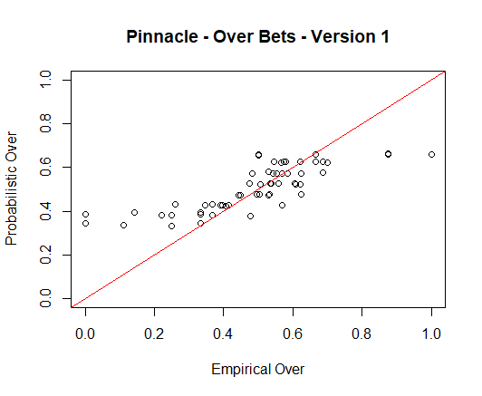

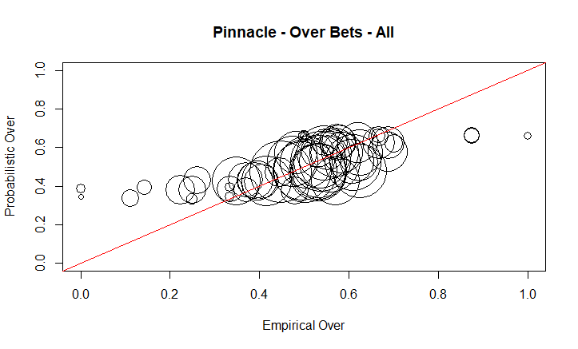

**Figure 2** - Pinnacle all

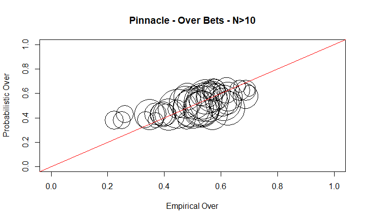

**Figure 3** - Pinnacle with higher reliability

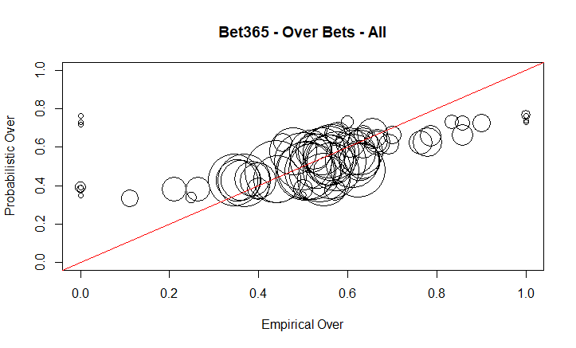

**Figure 4** - Bet365 all

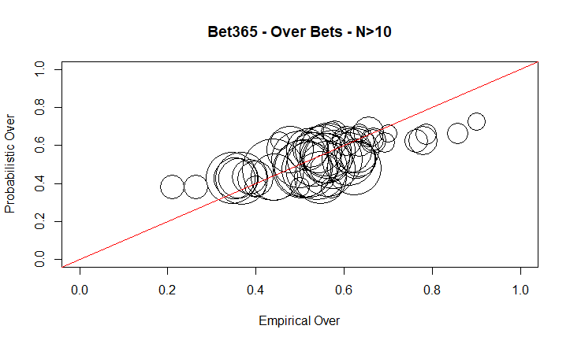

**Figure 5** - Bet365 with higher reliability

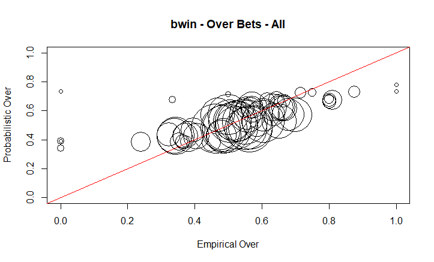

**Figure 6** - bwin all

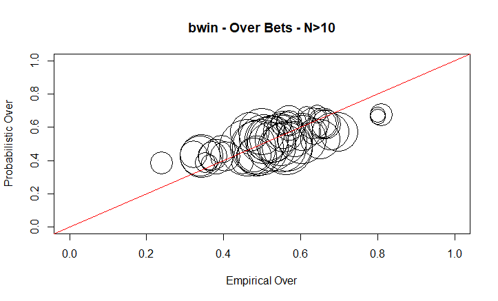

**Figure 7** - bwin with higher reliability

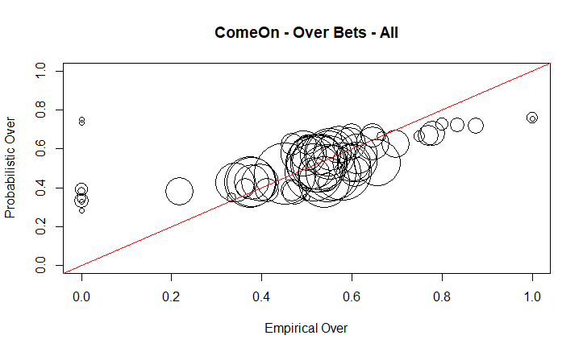

**Figure 8** - ComeOn all

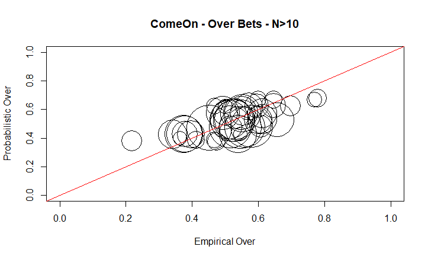

**Figure 9** - ComeOn with higher reliability

[figure not shown]

[figure not shown]

### 1.2. Task 1.b

In this task, the data obtained in the previous task for Pinnacle is shown in time dependency plots. In the following figures (**Figures 12 - 15**), empirical over and probabilistic over were drawn for the years 2011- 2018. The plots were given for separate bins to illustrate the time dependency better. In the plots, it can be seen that there is no certain trend in the quality of the estimation with time. However, the same conclusions drawn above can be made from these plots as well. For instance, the differences of the empirical and probabilistic over results are higher in the bin=(0.3,0.4) compared to others.

[figure not shown]

**Figure 12** - Pinnacle - Time dependent Emprirical vs Probabilistic Over - bin: (0.3,0.4).

[figure not shown]

**Figure 13** - Pinnacle - Time dependent Emprirical vs Probabilistic Over - bin: (0.4,0.5).

[figure not shown]

**Figure 14** - Pinnacle - Time dependent Emprirical vs Probabilistic Over - bin: (0.5,0.6).

[figure not shown]

**Figure 15** - Pinnacle - Time dependent Emprirical vs Probabilistic Over - bin: (0.6,0.7).

# 2. Task 2

This task aims to practice big data visiualization. In R, ggplot2 package is one of the most efficient ways of performing such trivial visualization tasks.

It is known from the odd details data that a bookmaker changes the odds in time. The focus is on odds for match results, in other words bet type: 1x2. Regarding the more than 5 million instances in the data, certain filters are applied. The data is narrowed to bet type = 1x2, odd = odd1, bookmaker = Pinnacle, Year = 2017 which contains 12798 instances exactly.

**Figure 16** is the plot for MatchId vs Odds. The information of the change in the odds is added via color gradient from blue to red implying first to last.

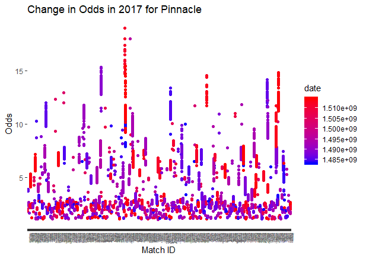

When the above plot is investigated, it is seen that there is no certain trend in the time varying odds meaning that there is no common trend for increase/decrease in the odd in time. If that were the case, the top-down color gradient would have been observed.

There is still some room to improve in this plot. Subgrouping the data regarding the number of odd changes (N) or months woulddecrease the datapoints in the plot and could give a better representation.

# 3. Appendix

## 3.1. Codes of Task 1

require(data.table) require(anytime) #require(dplyr) #require(plotly)

#read data matches = readRDS(“C:/Users/09172/Desktop/df9b1196-e3cf-4cc7-9159-f236fe738215_matches.rds”) odd_details = readRDS(“C:/Users/09172/Desktop/df9b1196-e3cf-4cc7-9159-f236fe738215_odd_details.rds”)

data.table(matches) data.table(odd_details)

matches=unique(matches) odd_details =unique(odd_details)

matches[,type:=NULL] #deleted since all are soccer

#convert the date from epoch #matches[,match_date:=anydate(date)] matches[,match_time:=anytime(date)] matches[,Year:=year(match_time)] # matches[,Month:=month(match_time)] # matches[,Weekday:=day(match_time)] # matches[,Hour:=hour(match_time)]

#filter na scores matches[is.na(score)]

#omit the rows with score = NA & divide the score into 2 matches_played = na.omit(matches,cols = “score”) matches_played[,c(“score1”,“score2”):=tstrsplit(score,‘:’)]

#add the scores up matches_played[,totscore:= (as.numeric(score1)+as.numeric(score2))] matches_played[,IsOver:=as.numeric(totscore>2)]

#filter over under 2.5 data =odd_details[betType==‘ou’ & totalhandicap==‘2.5’] data[,totalhandicap:=NULL]

#order data in ascending date odds_ov_un=data[order(matchId,oddtype,bookmaker,date)]

odds_ov_un_initial=data[,list(start_odd=odd[1]), by=list(matchId,oddtype,bookmaker)]

odds_ov_un_final=data[,list(final_odd=odd[.N]), by=list(matchId,oddtype,bookmaker)]

#transform to wide format  
wide_odds_initial=dcast(odds_ov_un_initial, matchId~oddtype+bookmaker, value.var=‘start_odd’)

## PINNACLE

#get pinnacle initial over under odds pinnacle_over_under=odds_ov_un_initial[bookmaker==‘Pinnacle’]

pinnacle_wide=dcast(pinnacle_over_under, matchId~oddtype, value.var=‘start_odd’)

# join odds with matches merged_matches1=merge(matches_played,pinnacle_wide,by=‘matchId’)

#setkey(matches,matchId) #setkey(pinnacle_wide,matchId) #joined_matches=pinnacle_wide[matches]

merged_matches1[,probOver:=1/over] merged_matches1[,probUnder:=1/under]

merged_matches1[,totalProb:=probOver+probUnder]

merged_matches1[,probOver:=probOver/totalProb] merged_matches1[,probUnder:=probUnder/totalProb]

merged_matches1=merged_matches1[complete.cases(merged_matches1)] merged_matches1[,totalProb:=NULL]

cutpoints=seq(0,1,0.05) merged_matches1[,odd_cut_over:=cut(probOver,cutpoints)]

summary_table1=merged_matches1[,list(empirical_over=mean(IsOver), probabilistic_over=mean(probOver),.N), by=list(Year,odd_cut_over)]

# list(Year) eklersen yillara göre de böler

summary_table1=summary_table1[order(Year)]

# plot(summary_table1[,list(empirical_over,probabilistic_over)], xlim = c(0,1), ylim = c(0,1), # xlab=‘Empirical Over’, ylab=‘Probabilistic Over’, main=“Pinnacle - Over Bets - Version 1”) # abline(0,1,col=‘red’)

plot(summary_table1[,list(empirical_over,probabilistic_over)], xlim = c(0,1), ylim = c(0,1),cex=sqrt(summary_table1$N), xlab=‘Empirical Over’, ylab=‘Probabilistic Over’, main=“Pinnacle - Over Bets - All”) abline(0,1,col=‘red’)

summary_table1_v2 =summary_table1[N>=10] plot(summary_table1_v2[,list(empirical_over,probabilistic_over)], xlim = c(0,1), ylim = c(0,1),cex=sqrt(summary_table1_v2$N), xlab=‘Empirical Over’, ylab=‘Probabilistic Over’, main=“Pinnacle - Over Bets - N>10”) abline(0,1,col=‘red’)

## BET365

#get bet365 initial over under odds bet365_over_under=odds_ov_un_initial[bookmaker==‘bet365’]

bet365_wide=dcast(bet365_over_under, matchId~oddtype, value.var=‘start_odd’)

# join odds with matches merged_matches2=merge(matches_played,bet365_wide,by=‘matchId’)

merged_matches2[,probOver:=1/over] merged_matches2[,probUnder:=1/under]

merged_matches2[,totalProb:=probOver+probUnder]

merged_matches2[,probOver:=probOver/totalProb] merged_matches2[,probUnder:=probUnder/totalProb]

merged_matches2=merged_matches2[complete.cases(merged_matches2)] merged_matches2[,totalProb:=NULL]

cutpoints=seq(0,1,0.05) merged_matches2[,odd_cut_over:=cut(probOver,cutpoints)]

summary_table2=merged_matches2[,list(empirical_over=mean(IsOver), probabilistic_over=mean(probOver),.N), by=list(Year,odd_cut_over)]

summary_table2=summary_table2[order(Year)]

plot(summary_table2[,list(empirical_over,probabilistic_over)], xlim = c(0,1), ylim = c(0,1),cex=sqrt(summary_table2$N), xlab=‘Empirical Over’, ylab=‘Probabilistic Over’, main=“Bet365 - Over Bets - All”) abline(0,1,col=‘red’)

summary_table2_v2 =summary_table2[N>=10] plot(summary_table2_v2[,list(empirical_over,probabilistic_over)], xlim = c(0,1), ylim = c(0,1),cex=sqrt(summary_table2_v2$N), xlab=‘Empirical Over’, ylab=‘Probabilistic Over’, main=“Bet365 - Over Bets - N>10”) abline(0,1,col=‘red’)

## BWIN

#get bwin initial over under odds bwin_over_under=odds_ov_un_initial[bookmaker==‘bwin’]

bwin_wide=dcast(bwin_over_under, matchId~oddtype, value.var=‘start_odd’)

# join odds with matches merged_matches3=merge(matches_played,bwin_wide,by=‘matchId’)

merged_matches3[,probOver:=1/over] merged_matches3[,probUnder:=1/under]

merged_matches3[,totalProb:=probOver+probUnder]

merged_matches3[,probOver:=probOver/totalProb] merged_matches3[,probUnder:=probUnder/totalProb]

merged_matches3=merged_matches3[complete.cases(merged_matches3)] merged_matches3[,totalProb:=NULL]

cutpoints=seq(0,1,0.05) merged_matches3[,odd_cut_over:=cut(probOver,cutpoints)]

summary_table3=merged_matches3[,list(empirical_over=mean(IsOver), probabilistic_over=mean(probOver),.N), by=list(Year,odd_cut_over)]

summary_table3=summary_table3[order(Year)]

plot(summary_table3[,list(empirical_over,probabilistic_over)], xlim = c(0,1), ylim = c(0,1),cex=sqrt(summary_table3$N), xlab=‘Empirical Over’, ylab=‘Probabilistic Over’, main=“bwin - Over Bets - All”) abline(0,1,col=‘red’)

summary_table3_v2 =summary_table3[N>=10] plot(summary_table3_v2[,list(empirical_over,probabilistic_over)], xlim = c(0,1), ylim = c(0,1),cex=sqrt(summary_table3_v2$N), xlab=‘Empirical Over’, ylab=‘Probabilistic Over’, main=“bwin - Over Bets - N>10”) abline(0,1,col=‘red’)

## COMEON

#get bwin initial over under odds comeon_over_under=odds_ov_un_initial[bookmaker==‘ComeOn’]

comeon_wide=dcast(comeon_over_under, matchId~oddtype, value.var=‘start_odd’)

# join odds with matches merged_matches4=merge(matches_played,comeon_wide,by=‘matchId’)

merged_matches4[,probOver:=1/over] merged_matches4[,probUnder:=1/under]

merged_matches4[,totalProb:=probOver+probUnder]

merged_matches4[,probOver:=probOver/totalProb] merged_matches4[,probUnder:=probUnder/totalProb]

merged_matches4=merged_matches4[complete.cases(merged_matches4)] merged_matches4[,totalProb:=NULL]

cutpoints=seq(0,1,0.05) merged_matches4[,odd_cut_over:=cut(probOver,cutpoints)]

summary_table4=merged_matches4[,list(empirical_over=mean(IsOver), probabilistic_over=mean(probOver),.N), by=list(Year,odd_cut_over)]

summary_table4=summary_table4[order(Year)]

plot(summary_table4[,list(empirical_over,probabilistic_over)], xlim = c(0,1), ylim = c(0,1),cex=sqrt(summary_table4$N), xlab=‘Empirical Over’, ylab=‘Probabilistic Over’, main=“ComeOn - Over Bets - All”) abline(0,1,col=‘red’)

summary_table4_v2 =summary_table4[N>=10] plot(summary_table4_v2[,list(empirical_over,probabilistic_over)], xlim = c(0,1), ylim = c(0,1),cex=sqrt(summary_table4_v2$N), xlab=‘Empirical Over’, ylab=‘Probabilistic Over’, main=“ComeOn - Over Bets - N>10”) abline(0,1,col=‘red’)

## YOUWIN

#get youwin initial over under odds youwin_over_under=odds_ov_un_initial[bookmaker==‘youwin’]

youwin_wide=dcast(youwin_over_under, matchId~oddtype, value.var=‘start_odd’)

# join odds with matches merged_matches5=merge(matches_played,comeon_wide,by=‘matchId’)

merged_matches5[,probOver:=1/over] merged_matches5[,probUnder:=1/under]

merged_matches5[,totalProb:=probOver+probUnder]

merged_matches5[,probOver:=probOver/totalProb] merged_matches5[,probUnder:=probUnder/totalProb]

merged_matches5=merged_matches5[complete.cases(merged_matches5)] merged_matches5[,totalProb:=NULL]

cutpoints=seq(0,1,0.05) merged_matches5[,odd_cut_over:=cut(probOver,cutpoints)]

summary_table5=merged_matches5[,list(empirical_over=mean(IsOver), probabilistic_over=mean(probOver),.N), by=list(Year,odd_cut_over)]

summary_table5=summary_table5[order(Year)]

plot(summary_table5[,list(empirical_over,probabilistic_over)], xlim = c(0,1), ylim = c(0,1),cex=sqrt(summary_table5$N), xlab=‘Empirical Over’, ylab=‘Probabilistic Over’, main=“Youwin - Over Bets - All”) abline(0,1,col=‘red’)

summary_table5_v2 =summary_table5[N>=10] plot(summary_table5_v2[,list(empirical_over,probabilistic_over)], xlim = c(0,1), ylim = c(0,1),cex=sqrt(summary_table5_v2$N), xlab=‘Empirical Over’, ylab=‘Probabilistic Over’, main=“Youwin - Over Bets - N>10”) abline(0,1,col=‘red’)

## PART 1.b

#Yearly change in Pinnacle odds (ou bettype & over odds)

cutpoints_b=seq(0,1,0.1) merged_matches_b=merged_matches1[,odd_cut_over:=cut(probOver,cutpoints_b)]

summary_table_b=merged_matches_b[,list(empirical_over=mean(IsOver), probabilistic_over=mean(probOver),.N), by=list(Year,odd_cut_over)]

summary_table_b=summary_table_b[order(Year)] data03 =summary_table_b[odd_cut_over=="(0.3,0.4]“] plot(data03[,list(Year,empirical_over)], ylim = c(0,1), main=”bin=(0.3,0.4]“, ylab=‘Probabilities’, col=”red“) par(new=TRUE) plot(data03[,list(Year, probabilistic_over)],ylab=’’, ylim = c(0,1)) legend(2016,1, c(”Empirical Over“,”Probabilistic Over“), pch =1, col =c(”black“,”red"))

data04 =summary_table_b[odd_cut_over=="(0.4,0.5]“] plot(data04[,list(Year,empirical_over)], ylim = c(0,1), main=”bin=(0.4,0.5]“, ylab=‘Probabilities’, col=”red“) par(new=TRUE) plot(data04[,list(Year, probabilistic_over)],ylab=’’, ylim = c(0,1)) legend(2016,1, c(”Empirical Over“,”Probabilistic Over“), pch =1, col =c(”black“,”red"))

data05 =summary_table_b[odd_cut_over=="(0.5,0.6]“] plot(data05[,list(Year,empirical_over)], ylim = c(0,1), main=”bin=(0.5,0.6]“, ylab=‘Probabilities’, col=”red“) par(new=TRUE) plot(data05[,list(Year, probabilistic_over)],ylab=’’, ylim = c(0,1)) legend(2016,1, c(”Empirical Over“,”Probabilistic Over“), pch =1, col =c(”black“,”red"))

data06 =summary_table_b[odd_cut_over=="(0.6,0.7]“] plot(data06[,list(Year,empirical_over)], ylim = c(0,1), main=”bin=(0.6,0.7]“, ylab=‘Probabilities’, col=”red“) par(new=TRUE) plot(data06[,list(Year, probabilistic_over)],ylab=’’, ylim = c(0,1)) legend(2016,1, c(”Empirical Over“,”Probabilistic Over“), pch =1, col =c(”black“,”red"))

## 3.2. Codes of Task 2

require(data.table) #require(dplyr) require(anytime)

#read data #matches = readRDS(“C:/Users/09172/Desktop/df9b1196-e3cf-4cc7-9159-f236fe738215_matches.rds”) odds = readRDS(“C:/Users/09172/Desktop/df9b1196-e3cf-4cc7-9159-f236fe738215_odd_details.rds”)

#data.table(matches) data.table(odds)

#matches=unique(matches) odds =unique(odds)

odds[,type:=NULL] #deleted since all are soccer odds[,match_time:=anytime(date)] odds[,Year:=year(match_time)]

odds_1x2=odds[betType==‘1x2’ & bookmaker==‘Pinnacle’] odds_1x2_odd1 = odds_1x2[oddtype==‘odd1’& Year==‘2017’]

odds_1x2_odd1[,c(“totalhandicap”,“oddtype”,“betType”,“bookmaker”, “Year”):=NULL]

#order data in ascending date odds_1x2_odd1=odds_1x2_odd1[order(matchId,date)] odds_1x2_odd1=odds_1x2_odd1[complete.cases(odds_1x2_odd1)] data=odds_1x2_odd1[,list(matchId, date, odd,.N),by=list(matchId)] data[, matchId:=NULL]

require(ggplot2) # # require(hexbin) # data.frame(data_all) # ggplot(data_all, aes(x=matchId,y=start_odd)) # +geom_col()

# +geom_dotplot(binaxis = “y”)

# geom_point() +geom_jitter() # + # scale_color_brewer(type=‘diverging’, palette=4) + # xlab(“Carats”) + ylab(“Price”) + ggtitle(“Diamonds”) #

##ÇALISTIIIII  
data$matchId=as.factor(data$matchId) head(data) ggplot(data, aes(x=matchId, y=odd))+ geom_point(aes(color=date)) + scale_color_gradient(low=“blue”, high=“red”)+ xlab(“Match ID”) + ylab(“Odds”) + theme(axis.text.x = element_text(angle = 90, hjust = 1, size=2))+ ggtitle(“Change in Odds in 2017 for Pinnacle”)

# #Nmax=max(data$N) # # # wide_data=dcast(data,unique(data$matchId) ~ odd ,fun.aggregate = NULL, # # value.var=‘odd’) # # #OLMADI # require(ggplot2) # ggplot(data, aes(x = unique(data$matchId), y = data$odd)) # data90=data[N>=90] # unique(data90$matchId) # # #OLMADI :(

# # #OLMADI VOL63576 # require(maps) # plot(data$N ~ data$odd, type=“n”) # map(“world”, add=TRUE, lwd=2, col=“gray”) # points(napol$Lat ~ napol$Lon, pch=16)